# Finding a model to represent a wind power curve from the manufacturer's table.

The purpose of this Jupyter/IPython notebook is to iind a model or a function based on the Power Curve table provided by the manufacturer.

The premises of this study is that sometimes, we have unplanned/unforeseen outages or shutdowns of wind turbines, but the wind speed data is still being collected. It would then be interesting to know what the power out put **would have been** if the outage hadn't happened.

The issue is that the Power Curve table is pretty limited, just giving the power output value for only a few specific wind speeds. What we want is being able to input any wind speed value (even a decimal value, e.g. 8.62 m/s) and return the corresponding power output based on the power curve.

Ideally, such a function should work for a single value, but also for an array/list of values (such as wind speed measurement series).

## Import Statements

```python
import numpy as np
import pandas as pd
import seaborn as sns
import matplotlib.pyplot as plt
from IPython.display import display
```

## Power Curve Used for the Analysis

The Power Curve used in this study has been extracted from the following research paper:

[Aggregated wind power and flexible load offering strategy](https://www.researchgate.net/publication/260633694_Aggregated_wind_power_and_flexible_load_offering_strategy), by Javad Mohammadi, Ashkan Rahimi-Kian and Mohammad Sadegh Ghazizadeh

[figure not shown]

## Creating Arrays from the Power Curve Table

```python
wind_spd = np.arange(4, 26)
wind_spd
```

```
array([ 4,  5,  6,  7,  8,  9, 10, 11, 12, 13, 14, 15, 16, 17, 18, 19, 20,
       21, 22, 23, 24, 25])
```

```python
power_part1 = np.array([15, 121, 251, 433, 667, 974, 1319, 1675, 2004, 2281, 2463])
```

### Finding a method to create an array of same values

#### Method 1

Using NumPy methods `.empty()` + `.fill()`

```python
power_part2 = np.empty(11, dtype=int)
power_part2.fill(2500)
power_part2
```

```
array([2500, 2500, 2500, 2500, 2500, 2500, 2500, 2500, 2500, 2500, 2500])
```

#### Using NumPy method `.full()`

```python
np.full(11, 2500)
```

```
array([2500, 2500, 2500, 2500, 2500, 2500, 2500, 2500, 2500, 2500, 2500])
```

```python
np.append(power_part1, power_part2)
```

```
array([  15,  121,  251,  433,  667,  974, 1319, 1675, 2004, 2281, 2463,
       2500, 2500, 2500, 2500, 2500, 2500, 2500, 2500, 2500, 2500, 2500])
```

```python
power = np.append(power_part1, np.full(11, 2500))
power
```

```
array([  15,  121,  251,  433,  667,  974, 1319, 1675, 2004, 2281, 2463,
       2500, 2500, 2500, 2500, 2500, 2500, 2500, 2500, 2500, 2500, 2500])
```

## Creating a DataFrame from the Arrays

```python
power_curve = pd.DataFrame({'wind_speed': wind_spd, 'power_kw': power})
power_curve
```

|  | wind_speed | power_kw |
| --- | --- | --- |
| 0 | 4 | 15 |
| 1 | 5 | 121 |
| 2 | 6 | 251 |
| 3 | 7 | 433 |
| 4 | 8 | 667 |
| 5 | 9 | 974 |
| 6 | 10 | 1319 |
| 7 | 11 | 1675 |
| 8 | 12 | 2004 |
| 9 | 13 | 2281 |
| 10 | 14 | 2463 |
| 11 | 15 | 2500 |
| 12 | 16 | 2500 |
| 13 | 17 | 2500 |
| 14 | 18 | 2500 |
| 15 | 19 | 2500 |
| 16 | 20 | 2500 |
| 17 | 21 | 2500 |
| 18 | 22 | 2500 |
| 19 | 23 | 2500 |
| 20 | 24 | 2500 |
| 21 | 25 | 2500 |

## Plotting and trying to find the best fit with Seaborn's `.regplot()`

After testing with some of the parameters (such as `lowess`, or `robust`), the best fit is by using `order` which tells the function to "estimate a polynomial regression" of the order specified

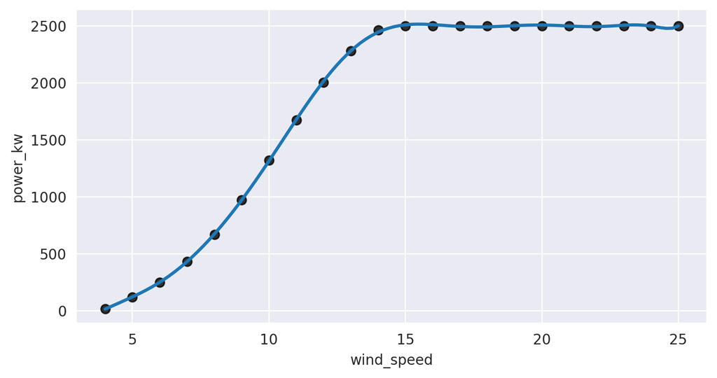

```python
plt.figure(figsize=(8,4), dpi=200)
with sns.axes_style('darkgrid'):
    reg = sns.regplot(data=power_curve,
                      x='wind_speed', y='power_kw',
                      order=12,
                      # lowess=True,
                      # robust=True,
                      ci=None,
                      scatter_kws = {'color': 'black', 's': 40},
                     )
    # reg.set_ylim(0, 3000)
plt.show()
```

After testing different values to obtain the best fit (by modifying the `order=` parameter (polynomial regression)), we have to go as high as a polynomial of order 12 to get a decent fit.

The issue is making the polynomial curve fit the slope part as well as the top flat part.

Perhaps, we could do the polynomial regression only on the curved part, and just separate our function in two like so:

```
f(x)={
    - polynomial when wind_speed < 15 m/s
    - 2500 kW when wind_speed >= 15 m/s}
```

### Polynomial Regression just on the part where `wind_speed < 15`

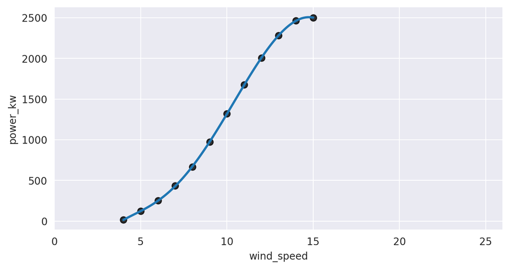

```python
plt.figure(figsize=(8,4), dpi=200)
with sns.axes_style('darkgrid'):
    reg = sns.regplot(data=power_curve[:12],
                      x='wind_speed', y='power_kw',
                      order=6,
                      ci=None,
                      scatter_kws = {'color': 'black', 's': 40},
                     )
    reg.set_xlim(0, 26)
plt.show()
```

This time, just an order of 6 or even 5 is enough to get a perfect fit.

But we probably want to add the value for when the wind_speed < 4 m/s, i.e. power = 0 kW

```python
# adding rows
power_curve.loc[-4] = [0, 0]
power_curve.loc[-3] = [1, 0]
power_curve.loc[-2] = [2, 0]
power_curve.loc[-1] = [3, 0]
power_curve.tail()
```

|  | wind_speed | power_kw |
| --- | --- | --- |
| 21 | 25 | 2500 |
| -4 | 0 | 0 |
| -3 | 1 | 0 |
| -2 | 2 | 0 |
| -1 | 3 | 0 |

```python
power_curve.index = power_curve.index + 4  # shifting index
power_curve = power_curve.sort_index()     # sorting by index
```

```python
with pd.option_context('display.max_rows', 20):
    display(power_curve)
```

|  | wind_speed | power_kw |
| --- | --- | --- |
| 0 | 0 | 0 |
| 1 | 1 | 0 |
| 2 | 2 | 0 |
| 3 | 3 | 0 |
| 4 | 4 | 15 |
| ... | ... | ... |
| 21 | 21 | 2500 |
| 22 | 22 | 2500 |
| 23 | 23 | 2500 |
| 24 | 24 | 2500 |
| 25 | 25 | 2500 |

26 rows × 2 columns

Now, we have a power curve table with four more points, where the power is 0 when the wind speed is at 0, 1, 2 or 3 m/s.

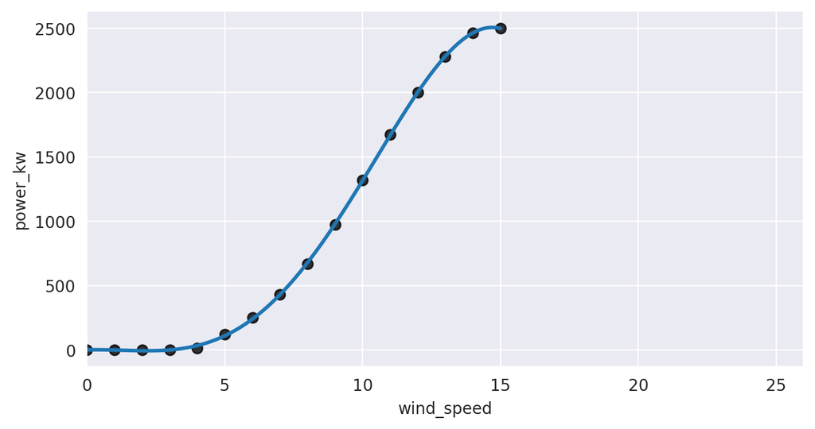

```python
plt.figure(figsize=(8,4), dpi=200)
with sns.axes_style('darkgrid'):
    reg = sns.regplot(data=power_curve[:16],
                      x='wind_speed', y='power_kw',
                      order=6,
                      ci=None,
                      scatter_kws = {'color': 'black', 's': 40},
                     )
    reg.set_xlim(0, 26)
plt.show()
```

**Result:** An order of 4 seems enough, or 5 or 6 to be sure.

Otherwise, if we exclude wind_speed < 4, we can just have it zero. So essentially, we have a three parts function:

```
f(x)={
    - 0 kW when wind_speed < 4 m/s
    - polynomial when 4 m/s >= wind_speed > 15 m/s
    - 2500 kW when wind_speed >= 15 m/s}
```

**Issue:** `regplot` is a wonderful tool when we want to get a trend from a big sample of points, and find some relational behaviour between our x and y by trying to fit a line in our scatter plot. But it's just visual, it doesn't return us the actual function to be later re-used.

After some search, a few options are available:

- SymPy library, using the `interpolate()` function
- NumPy library, using the `polyfit()` function
- Scikit-learn library, using `PolynomialFeatures` and `fit_transform`, see [link](https://scikit-learn.org/stable/modules/linear_model.html#polynomial-regression-extending-linear-models-with-basis-functions)
- SciPy library, using the `.optimize.curve_fit()` function, see [documentation](https://docs.scipy.org/doc/scipy/reference/generated/scipy.optimize.curve_fit.html)

## Finding the best polynomial fit with SymPy

### Import statements for SymPy

```python
from sympy.polys.polyfuncs import interpolate
import sympy as sy

# If we assume x as a symbol for the entire notebook,
# then next statement OK, otherwise comment it out

# from sympy.abc import x
```

### Converting DataFrame into list of tuples

Having a list points (list of (x,y) coordinates) makes it easier for the SymPy interpolate function.

```python
list_pts_PC = list(power_curve.itertuples(index=False, name=None))
list_pts_PC
```

```
[(0, 0),
 (1, 0),
 (2, 0),
 (3, 0),
 (4, 15),
 (5, 121),
 (6, 251),
 (7, 433),
 (8, 667),
 (9, 974),
 (10, 1319),
 (11, 1675),
 (12, 2004),
 (13, 2281),
 (14, 2463),
 (15, 2500),
 (16, 2500),
 (17, 2500),
 (18, 2500),
 (19, 2500),
 (20, 2500),
 (21, 2500),
 (22, 2500),
 (23, 2500),
 (24, 2500),
 (25, 2500)]
```

### Interpolate the Power Curve

```python
x = sy.Symbol('x')  # defining x, just for the interpolate
pc_equation = interpolate(list_pts_PC, x)
```

```python
type(pc_equation)
```

```
sympy.core.add.Add
```

### Display SymPy equation

```python
# "Not pretty", pure text... "low quality"
print(pc_equation)
```

[output not shown]

```python
# Pretty, pure text... "medium quality"
sy.pprint(pc_equation)
```

```
                 25                       24                        23
         121523⋅x                1324733⋅x               220916669⋅x
- ─────────────────────── + ────────────────────── - ────────────────────── +
  44960029111104307200000   1586824556862504960000   1814176613255086080000

                  22                     21                      20
    150479481743⋅x          53527870553⋅x         1744261084889⋅x        24377
─────────────────────── - ──────────────────── + ──────────────────── - ──────
13488008733331292160000   74314097704304640000   50048269882490880000   185785

           19                     18                       17
718442603⋅x      635626817626963⋅x      13755454853687891⋅x     14539711505101
────────────── + ──────────────────── - ───────────────────── + ──────────────
24426076160000   16133981738434560000    14341317100830720000    7592461994557

      16                        15                        14
4707⋅x     4397288206040025497⋅x     3685763237432594569⋅x     210860517565707
──────── - ─────────────────────── + ─────────────────────── - ───────────────
440000       13919513656688640000       852215121838080000        428292727898

       13                            12                         11
72709⋅x     38904441412567820247887⋅x     14270323131367695803⋅x     448729510
───────── + ─────────────────────────── - ──────────────────────── + ─────────
112000          83517081940131840000          3905587445760000           18981

                10                          9                           8
38074304796933⋅x     239128527993465434497⋅x    5200293777691469383723⋅x    39
────────────────── - ──────────────────────── + ───────────────────────── - ──
15498639360000           1909798974720000            9684262748160000

                         7                               6
10150035200512147833443⋅x    20894399308695791282822021⋅x    34043077557087497
────────────────────────── + ───────────────────────────── - ─────────────────
  2128789257154560000             4257578514309120000             342349149542

          5                             4                            3
03174069⋅x    190325223312559726008823⋅x    26355426581961741964457⋅x    26730
─────────── + ─────────────────────────── - ────────────────────────── + ─────
400000             13009267682611200             1806842733696000

                2
18654716389949⋅x    176024872595257⋅x
───────────────── - ─────────────────
307286179200             76488984
```

```python
# Pretty, pure text... "medium quality"
# both expressions return the same result
sy.sympify(pc_equation)
display(pc_equation)
```

$\displaystyle - \frac{121523 x^{25}}{44960029111104307200000} + \frac{1324733 x^{24}}{1586824556862504960000} - \frac{220916669 x^{23}}{1814176613255086080000} + \frac{150479481743 x^{22}}{13488008733331292160000} - \frac{53527870553 x^{21}}{74314097704304640000} + \frac{1744261084889 x^{20}}{50048269882490880000} - \frac{24377718442603 x^{19}}{18578524426076160000} + \frac{635626817626963 x^{18}}{16133981738434560000} - \frac{13755454853687891 x^{17}}{14341317100830720000} + \frac{145397115051014707 x^{16}}{7592461994557440000} - \frac{4397288206040025497 x^{15}}{13919513656688640000} + \frac{3685763237432594569 x^{14}}{852215121838080000} - \frac{21086051756570772709 x^{13}}{428292727898112000} + \frac{38904441412567820247887 x^{12}}{83517081940131840000} - \frac{14270323131367695803 x^{11}}{3905587445760000} + \frac{44872951038074304796933 x^{10}}{1898115498639360000} - \frac{239128527993465434497 x^{9}}{1909798974720000} + \frac{5200293777691469383723 x^{8}}{9684262748160000} - \frac{3910150035200512147833443 x^{7}}{2128789257154560000} + \frac{20894399308695791282822021 x^{6}}{4257578514309120000} - \frac{3404307755708749703174069 x^{5}}{342349149542400000} + \frac{190325223312559726008823 x^{4}}{13009267682611200} - \frac{26355426581961741964457 x^{3}}{1806842733696000} + \frac{2673018654716389949 x^{2}}{307286179200} - \frac{176024872595257 x}{76488984}$

### Passing an array into the function

**Reminder:** The NumPy function `linspace()` returns evenly spaced numbers over a specified interval: `np.linspace(start, stop, nb_of_points)`

```python
np.linspace(0, 30, 31)
```

```
array([ 0.,  1.,  2.,  3.,  4.,  5.,  6.,  7.,  8.,  9., 10., 11., 12.,
       13., 14., 15., 16., 17., 18., 19., 20., 21., 22., 23., 24., 25.,
       26., 27., 28., 29., 30.])
```

```python
# After having copy-pasted the equation from the first raw output
def my_function(x):  # we can later call it f(x) for simplicity
    return -121523*x**25/44960029111104307200000 + 1324733*x**24/1586824556862504960000 - 220916669*x**23/1814176613255086080000 + 150479481743*x**22/13488008733331292160000 - 53527870553*x**21/74314097704304640000 + 1744261084889*x**20/50048269882490880000 - 24377718442603*x**19/18578524426076160000 + 635626817626963*x**18/16133981738434560000 - 13755454853687891*x**17/14341317100830720000 + 145397115051014707*x**16/7592461994557440000 - 4397288206040025497*x**15/13919513656688640000 + 3685763237432594569*x**14/852215121838080000 - 21086051756570772709*x**13/428292727898112000 + 38904441412567820247887*x**12/83517081940131840000 - 14270323131367695803*x**11/3905587445760000 + 44872951038074304796933*x**10/1898115498639360000 - 239128527993465434497*x**9/1909798974720000 + 5200293777691469383723*x**8/9684262748160000 - 3910150035200512147833443*x**7/2128789257154560000 + 20894399308695791282822021*x**6/4257578514309120000 - 3404307755708749703174069*x**5/342349149542400000 + 190325223312559726008823*x**4/13009267682611200 - 26355426581961741964457*x**3/1806842733696000 + 2673018654716389949*x**2/307286179200 - 176024872595257*x/76488984
```

```python
my_function(np.linspace(0, 30, 31))
```

```
array([0.0, 9.313225746154785e-10, 3.166496753692627e-08,
       -7.972121238708496e-07, 14.999998707324266, 121.00002004392445,
       250.99959169328213, 432.99863643571734, 666.9938658252358,
       973.9672705605626, 1319.0866488553584, 1674.879140138626,
       2002.4699810445309, 2280.727921064943, 2451.5286014303565,
       2468.4490520879626, 2463.2134055644274, 2510.757635757327,
       2272.0152682214975, 2122.32172165066, 2410.6682370379567,
       7980.190907515585, 4724.130456209183, -15866.954844027758,
       -33077.819448292255, 107463.25658311695, -102365120.25857961,
       -2538273114.085485, -32815293924.954514, -294539924558.26117,
       -2061250819577.9875], dtype=object)
```

We gave 31 wind_speed values to our function and it returned an array of 31 power_kw values.

So now we can just give our function any x array, for it to return the y array.

Let's test it by plotting a curve with a big input array.

### Plotting the equation

```
(0.0, 3000.0)
```

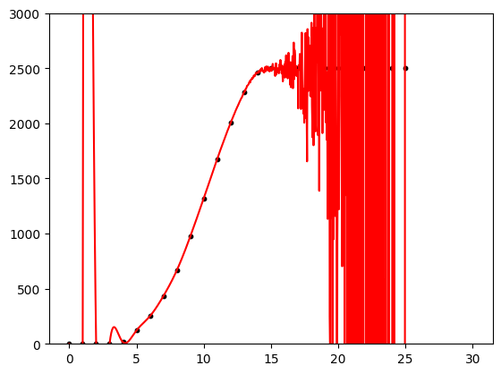

```python
# re-defining x, for the scatter (black points)
x = power_curve.wind_speed
y = power_curve.power_kw

plt.figure()
plt.scatter(x, y, c='black', s=10)

# re-defining x, with 1000 points, wind_speed from 0 to 30 m/s
x = np.linspace(0, 30, 1000)

plt.plot(x, my_function(x), c='red')
plt.ylim(0, 3000)
```

OMG, this is just crap...

### Trying again with just the slope portion of the power curve

#### First testing if list of Tuples necessary

```
interpolate(power_curve.wind_speed.values, power_curve.power_kw.values, x)
```

We get an error: "TypeError: interpolate() takes 2 positional arguments but 3 were given"

--> So, yes, necessary

#### Using slicing to get the desired part of the power curve

```python
power_curve.iloc[4:16]
```

|  | wind_speed | power_kw |
| --- | --- | --- |
| 4 | 4 | 15 |
| 5 | 5 | 121 |
| 6 | 6 | 251 |
| 7 | 7 | 433 |
| 8 | 8 | 667 |
| 9 | 9 | 974 |
| 10 | 10 | 1319 |
| 11 | 11 | 1675 |
| 12 | 12 | 2004 |
| 13 | 13 | 2281 |
| 14 | 14 | 2463 |
| 15 | 15 | 2500 |

```python
list_pts_PC = list(power_curve.iloc[4:16].itertuples(index=False, name=None))
x = sy.Symbol('x')  # defining x, just for the interpolate
pc_equation = interpolate(list_pts_PC, x)
print(pc_equation)
```

```
43*x**11/712800 - 23087*x**10/3628800 + 218377*x**9/725760 - 101827*x**8/12096 + 13365697*x**7/86400 - 338520911*x**6/172800 + 1807280623*x**5/103680 - 7902450653*x**4/72576 + 424130482537*x**3/907200 - 22056658927*x**2/16800 + 8586740077*x/3960 - 1594314
```

```python
def f(x):
    return 43*x**11/712800 - 23087*x**10/3628800 + 218377*x**9/725760 - 101827*x**8/12096 + 13365697*x**7/86400 - 338520911*x**6/172800 + 1807280623*x**5/103680 - 7902450653*x**4/72576 + 424130482537*x**3/907200 - 22056658927*x**2/16800 + 8586740077*x/3960 - 1594314
```

```
(0.0, 3000.0)
```

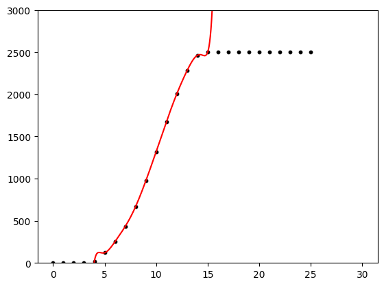

```python
# re-defining x, for the scatter (black points)
x = power_curve.wind_speed
y = power_curve.power_kw

plt.figure()
plt.scatter(x, y, c='black', s=10)

# re-defining x, with 1000 points, wind_spd from 0 to 30 m/s
x = np.linspace(0, 30, 1000)

plt.plot(x, f(x), c='red')
plt.ylim(0, 3000)
```

**Result:** This fits more or less..

We could imagine a function similar to this, but taking the lower and upper limits into account.

### Defining a custom power curve function

```python
def power_curve_blabla_WF(wind_spd):
    '''
    First version of power curve function,
    return a single value or an array, depending on the type of input
    '''
    def f(x):
        if x < 4 or x > 30: # taking cut-in and cut-out into account
            return 0
        elif x > 15:
            return 2500
        else:
            return 43*x**11/712800 - 23087*x**10/3628800 + 218377*x**9/725760 - 101827*x**8/12096 + 13365697*x**7/86400 - 338520911*x**6/172800 + 1807280623*x**5/103680 - 7902450653*x**4/72576 + 424130482537*x**3/907200 - 22056658927*x**2/16800 + 8586740077*x/3960 - 1594314

    type_w = type(wind_spd)
    if type_w in [int, float]:
        return f(wind_spd)
    elif type_w in [pd.core.series.Series, np.ndarray, list]:
        result = np.array([])
        for value in wind_spd:
            result = np.append(result, f(value))
        return result
    else:
        print("Input type not not appropriate.")
```

Testing with individual values:

```python
print(power_curve_blabla_WF(-4))
print(power_curve_blabla_WF(0))
print(power_curve_blabla_WF(2))
print(power_curve_blabla_WF(4))
print(power_curve_blabla_WF(8))
print(power_curve_blabla_WF(14))
print(power_curve_blabla_WF(20))
print(power_curve_blabla_WF(25))
print(power_curve_blabla_WF(32))
print(power_curve_blabla_WF(64))
```

```
0
0
0
15.0
667.0
2463.000001076609
2500
2500
0
0
```

Testig with an array

```python
power_curve_blabla_WF([6, 8, 12, 16, 22])
```

```
array([ 251.        ,  667.        , 2003.99999989, 2500.        ,
       2500.        ])
```

### Plotting the custom equation

```
(0.0, 3000.0)
```

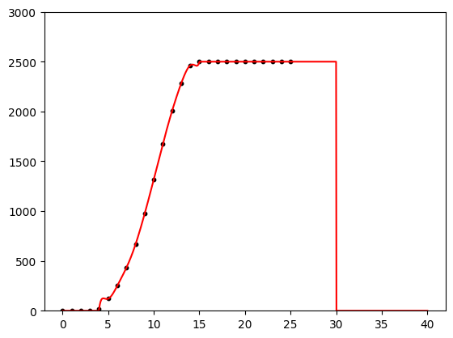

```python
# re-defining x, for the scatter (black points)
x = power_curve.wind_speed
y = power_curve.power_kw

plt.figure()
plt.scatter(x, y, c='black', s=10)

# re-defining x, with 1000 points, wind_spd from 0 to 30 m/s
x = np.linspace(0, 40, 1000)

plt.plot(x, power_curve_blabla_WF(x), c='red')
plt.ylim(0, 3000)
```

**Result: Almost a perfect fit :)**

Although, still not so good around the 5 and 15 m/s area.

**Issue:** The function actually only cares about passing through the points. It probably returns the most perfect function which passes right through those points, but then it doesn't care about the in-between. Also we can't adjust the order of the polynomial ourselves. In the last case, we used an order 11 polynomial, which is probably overrated for fitting the simple slope part. A too high order results in some overshoot. This method would probably work with a big sample of data, but we only have limited points in our power curve table.

We need to find a function that gives us some power in choosing the polynomial order.

## Finding a polynomial fit with NumPy `.polyfit()`

All we need to do is call the function, give it the x values and y values and the degree.

We only try with degree 5 first.

```python
x = power_curve.wind_speed.values
y = power_curve.power_kw.values

poly = np.polyfit(x, y, deg=5)
```

**`.polyfit()`** returns an array of polynomial coefficients, highest power first.

```python
type(poly)
```

```
numpy.ndarray
```

```python
print(poly)
```

```
[ 4.40508241e-03 -1.97438860e-01  1.45261249e+00  2.82556408e+01
 -1.48893452e+02  8.81837464e+01]
```

Once we have our `poly` polynomial, we can use **`.polyval()`** to return the result.

```python
np.polyval(poly, x)
```

```
array([  88.18374642,  -31.1944858 ,  -87.97775306,  -79.89741697,
         -8.36615199,  122.05066445,  304.16356184,  528.68758649,
        784.77091143, 1060.52344625, 1343.54544705, 1621.45612628,
       1882.42226265, 2115.68681102, 2312.09751229, 2464.63550326,
       2568.94392659, 2623.85654058, 2631.92632916, 2599.95411173,
       2539.51715304, 2467.49777312, 2406.61195713, 2385.93796526,
       2441.44494262, 2616.52152914])
```

**`.polyval()`** takes an array of polynomial coefficients (that we created with `.polyfit()`, an array of inputs (x) and returns the output array.

### Plotting the polynamial (degree 5), with the original data

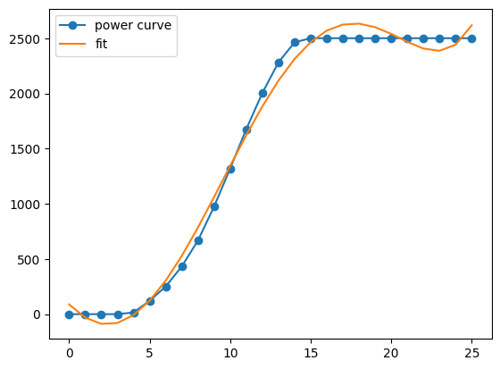

```python
# plt.plot(x, y)
fig, ax = plt.subplots()
ax.plot(x, y, label='power curve', marker='o')
ax.plot(x, np.polyval(poly, x), label='fit')
ax.legend()
```

### Trying `.polyval()` with just one value

```python
np.polyval(poly, 12)
```

```
1882.4222626486567
```

I can use the found polynome `poly` and the `.polyval()` method to output the power from the wind speed.

### Trying `.polyval()` with different arrays

```python
x
```

```
array([ 0,  1,  2,  3,  4,  5,  6,  7,  8,  9, 10, 11, 12, 13, 14, 15, 16,
       17, 18, 19, 20, 21, 22, 23, 24, 25], dtype=int64)
```

```python
np.polyval(poly, x)
```

```
array([  88.18374642,  -31.1944858 ,  -87.97775306,  -79.89741697,
         -8.36615199,  122.05066445,  304.16356184,  528.68758649,
        784.77091143, 1060.52344625, 1343.54544705, 1621.45612628,
       1882.42226265, 2115.68681102, 2312.09751229, 2464.63550326,
       2568.94392659, 2623.85654058, 2631.92632916, 2599.95411173,
       2539.51715304, 2467.49777312, 2406.61195713, 2385.93796526,
       2441.44494262, 2616.52152914])
```

```python
np.polyval(poly, np.linspace(0,30,31))
```

```
array([  88.18374642,  -31.1944858 ,  -87.97775306,  -79.89741697,
         -8.36615199,  122.05066445,  304.16356184,  528.68758649,
        784.77091143, 1060.52344625, 1343.54544705, 1621.45612628,
       1882.42226265, 2115.68681102, 2312.09751229, 2464.63550326,
       2568.94392659, 2623.85654058, 2631.92632916, 2599.95411173,
       2539.51715304, 2467.49777312, 2406.61195713, 2385.93796526,
       2441.44494262, 2616.52152914, 2962.50446944, 3539.20722273,
       4415.44857268, 5669.58123735, 7390.02047904])
```

### Plotting the polynamial (degree 5), with 1000 points

```
(0.0, 3000.0)
```

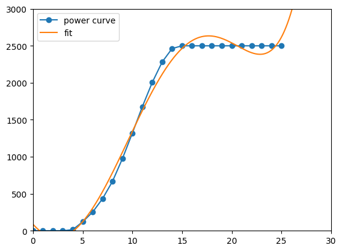

```python
x = power_curve.wind_speed.values

plt.plot(x, y, label='power curve', marker='o')

x = np.linspace(0, 31, 1000)
plt.plot(x, np.polyval(poly, x), label='fit') # don't forget x and y!
plt.legend()
plt.xlim(0, 30)
plt.ylim(0, 3000)
```

### Testing with higher order

```
(0.0, 3000.0)
```

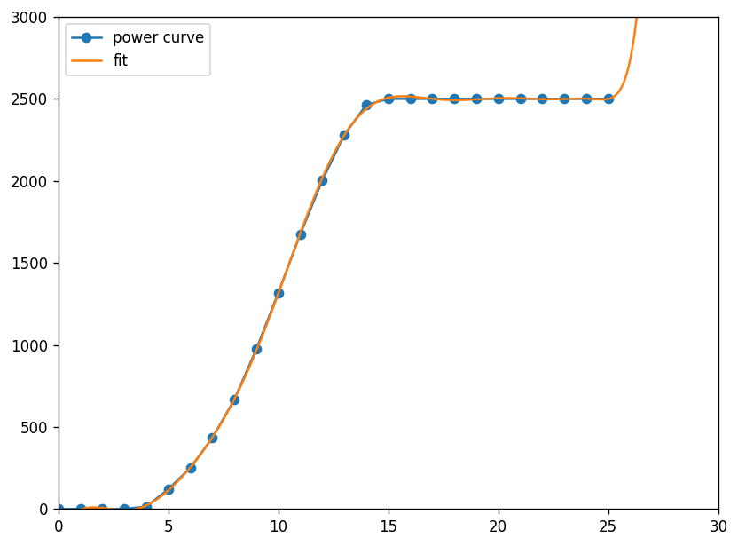

```python
x = power_curve.wind_speed.values
poly = np.polyfit(x, y, deg=12)

plt.figure(figsize=(8,6), dpi=120)
plt.plot(x, y, label='power curve', marker='o')

x = np.linspace(0, 31, 1000)
plt.plot(x, np.polyval(poly, x), label='fit') # don't forget x and y!
plt.legend()
plt.xlim(0, 30)
plt.ylim(0, 3000)
```

Just like with the Seaborn regression line tool, a polynome of order 12 seems to work really well.

Still, let's try to find a good fit for the slope part of the curve, just like before, but with `.polyfit()` this time.

### Perfect fit for slope part with NumPy's `polyfit`

```
(0.0, 3000.0)
```

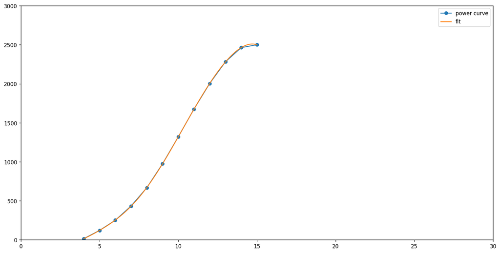

```python
x = power_curve[4:16].wind_speed.values
y = power_curve[4:16].power_kw.values

poly = np.polyfit(x, y, deg=8)

plt.figure(figsize=(16,8), dpi=120)
plt.plot(x, y, label='power curve', marker='o')

x = np.linspace(4, 15, 1000)
plt.plot(x, np.polyval(poly, x), label='fit') # don't forget x and y!
plt.legend()
plt.xlim(0, 30)
plt.ylim(0, 3000)
```

**Result:** If worry about performance and order of polynome too big, **order 4** just for this part of the power curve is **actually fine, order 5 pretty much perfect, onwards until order 8.**

We can use this polynomial in a custom function.

### Custom Power Curve function with NumPy

```python
def power_curve_blabla_WF_v2(wind_spd):
    '''
    Second version of power curve function, using NumPy's polyval function.
    Assuming a polynome has been processed with polyfit beforehands.
    Return a single value or an array, depending on the type of input.
    '''
    def f(x):
        if x < 4 or x > 30:
            return 0
        elif x > 15:
            return 2500
        else:
            return np.polyval(poly, x)

    type_w = type(wind_spd)
    if type_w in [int, float]:
        return f(wind_spd)
    elif type_w in [pd.core.series.Series, np.ndarray, list]:
        result = np.array([])
        for value in wind_spd:
            result = np.append(result, f(value))
        return result
    else:
        print("Input type not not appropriate.")
```

### Testing our Custom Power Curve Function

#### Testing with one value

```python
power_curve_blabla_WF_v2(13)
```

```
2279.92910108538
```

#### Testing with a Series or List

```python
power_curve_blabla_WF_v2([-5, 2, 4, 6, 8, 14, 15, 16, 18, 20, 24, 25, 29, 30, 31, 32])
```

```
array([   0.        ,    0.        ,   15.08007859,  252.95027496,
        669.85149061, 2463.38485895, 2499.94504644, 2500.        ,
       2500.        , 2500.        , 2500.        , 2500.        ,
       2500.        , 2500.        ,    0.        ,    0.        ])
```

**Final Result: From there, I can use this function with a Series of wind speeds as input and get a Series of power (kW) as output, and I can use this result in a Pandas DataFrame and all.**

**Data from Excel or .csv files can, of course, be easily imported and transformed into Pandas DataFrame and we can do lots of data manipulation, just like in the other IPython/Jupyter Notebooks.**

### Improvements ideas

I could probably define a function, which takes a power curve DataFrame or array (values from the manufacturer's table), finds the cut-in and cut-out value (or it could also take 3 inputs values such as the cut-in and cut-out --to know when to return 0-- and the plateau value, when the Power Curve reaches the Pnom or Pmax and stays at that value for a while), and finally returns the power-curve function.

So basically, I would have **a function which returns the Power Curve function based on a sample of data. And then I could use the PC function for further analysis.**

### For illustration purpose, plotting the Custom Power Curve Function (v2)

```
(0.0, 3000.0)
```

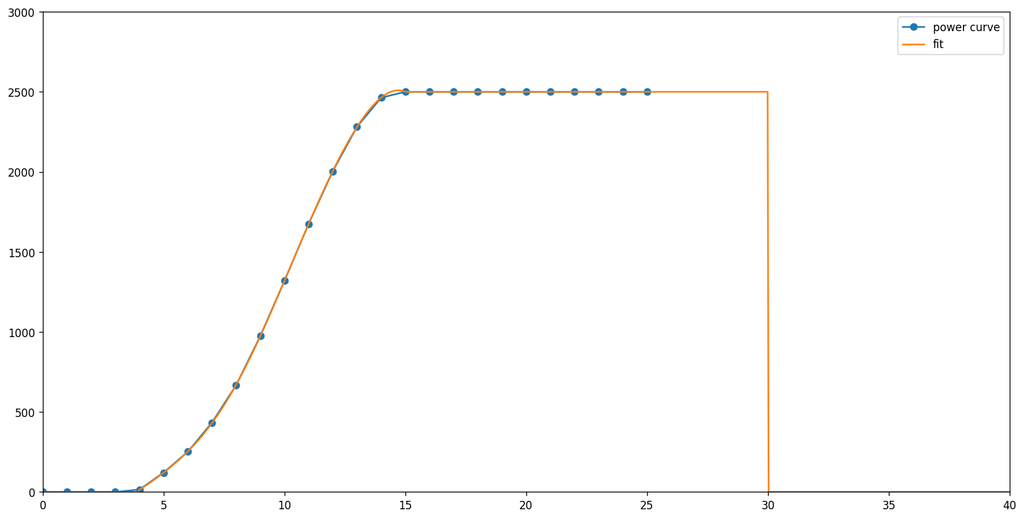

```python
x = power_curve.wind_speed.values
y = power_curve.power_kw.values

plt.figure(figsize=(16,8), dpi=120)
plt.plot(x, y, label='power curve', marker='o')

x = np.linspace(0, 40, 1000)
plt.plot(x, power_curve_blabla_WF_v2(x), label='fit') # don't forget x and y!
plt.legend()
plt.xlim(0, 40)
plt.ylim(0, 3000)
```